# Loan Approval Prediction Analysis

## Explainable Binary Classification for Loan Approval Decisions

**M516 Business Project in Big Data & AI — Gisma University of Applied Sciences**

### Business Problem

A bank's loan officer must decide, for each applicant, whether to approve or reject a loan. Manual review is slow and inconsistent. This project builds an ML model that:

1. Predicts **LoanApproved** (Yes/No) from the applicant's financial profile
2. Explains **why** each decision was made using SHAP values

The second point is not optional: under GDPR Article 22, applicants have a right to a meaningful explanation of automated decisions affecting them.

## 0 · Imports & Configuration

All tunable parameters live here. Changing a number here changes it everywhere — no hunting through the notebook.

Think of this cell as the project's control panel — every important setting is defined here once, so the rest of the notebook just reads from it rather than repeating itself.

```python
import warnings, json
from pathlib import Path

# ── Data ──────────────────────────────────────────────────────────────────────
import numpy as np
import pandas as pd

# ── Visualisation ─────────────────────────────────────────────────────────────
import matplotlib.pyplot as plt
import seaborn as sns

# ── Modelling ─────────────────────────────────────────────────────────────────
from sklearn.pipeline import Pipeline
from sklearn.compose import ColumnTransformer
from sklearn.preprocessing import StandardScaler, OneHotEncoder
from sklearn.impute import SimpleImputer
from sklearn.linear_model import LogisticRegression
from sklearn.metrics import (
    classification_report, roc_auc_score, average_precision_score,
    RocCurveDisplay, PrecisionRecallDisplay, ConfusionMatrixDisplay
)
from xgboost import XGBClassifier
import shap

warnings.filterwarnings("ignore")
shap.initjs()           # enables SHAP force plots in Jupyter

# ── Configuration (all design choices in one place) ───────────────────────────
# DATA_PATH was previously pointing to the local file. Now it points to the public GitHub URL.
DATA_PATH   = "https://raw.githubusercontent.com/sujay078/Loan-Approval-XAI-/main/Loan.csv"
ARTIFACTS   = Path("../artifacts")
ARTIFACTS.mkdir(exist_ok=True)

TARGET      = "LoanApproved"             # binary: 1 = approved, 0 = rejected
DATE_COL    = "ApplicationDate"          # used for the time-based split
# RiskScore is excluded: it is a pre-computed risk label derived from the same
# inputs → including it would be TARGET LEAKAGE and inflate results dishonestly.
DROP_COLS   = ["RiskScore", DATE_COL]

TEST_SIZE   = 0.20     # hold out the most recent 20% as the test set
RANDOM_SEED = 42

print("✓ Configuration loaded.")
```

```
✓ Configuration loaded.
```

## 1 · Load Data & Inspect

We load the raw CSV file and immediately parse the date column — that date is what lets us do a time-aware split later instead of a random shuffle.

```python
df = pd.read_csv(str(DATA_PATH))
if DATE_COL in df.columns:
    df[DATE_COL] = pd.to_datetime(df[DATE_COL], errors="coerce")

print(f"Shape: {df.shape}")
print(f"Columns: {df.columns.tolist()}")
df.head(3)
```

```
Shape: (20000, 36)
Columns: ['ApplicationDate', 'Age', 'AnnualIncome', 'CreditScore', 'EmploymentStatus', 'EducationLevel', 'Experience', 'LoanAmount', 'LoanDuration', 'MaritalStatus', 'NumberOfDependents', 'HomeOwnershipStatus', 'MonthlyDebtPayments', 'CreditCardUtilizationRate', 'NumberOfOpenCreditLines', 'NumberOfC…
```

|  | ApplicationDate | Age | AnnualIncome | CreditScore | EmploymentStatus | EducationLevel | Experience | LoanAmount | LoanDuration | MaritalStatus | ... | MonthlyIncome | UtilityBillsPaymentHistory | JobTenure | NetWorth | BaseInterestRate | InterestRate | MonthlyLoanPayment | TotalDebtToIncomeRatio | LoanApproved | RiskScore |
| --- | --- | --- | --- | --- | --- | --- | --- | --- | --- | --- | --- | --- | --- | --- | --- | --- | --- | --- | --- | --- | --- |
| 0 | 2018-01-01 | 45 | 39948 | 617 | Employed | Master | 22 | 13152 | 48 | Married | ... | 3329.000000 | 0.724972 | 11 | 126928 | 0.199652 | 0.227590 | 419.805992 | 0.181077 | 0 | 49.0 |
| 1 | 2018-01-02 | 38 | 39709 | 628 | Employed | Associate | 15 | 26045 | 48 | Single | ... | 3309.083333 | 0.935132 | 3 | 43609 | 0.207045 | 0.201077 | 794.054238 | 0.389852 | 0 | 52.0 |
| 2 | 2018-01-03 | 47 | 40724 | 570 | Employed | Bachelor | 26 | 17627 | 36 | Married | ... | 3393.666667 | 0.872241 | 6 | 5205 | 0.217627 | 0.212548 | 666.406688 | 0.462157 | 0 | 52.0 |

3 rows × 36 columns

Think of this as a health check on the data — before training anything we need to know which columns have gaps, what types of values each column holds, and whether anything looks suspicious.

```python
# Data types + missing values at a glance
missing = df.isnull().sum()
summary = pd.DataFrame({
    "dtype":   df.dtypes,
    "missing": missing,
    "missing%": (missing / len(df) * 100).round(2),
    "nunique": df.nunique(),
})
print(summary.to_string())
```

```
                                     dtype  missing  missing%  nunique
ApplicationDate             datetime64[ns]        0       0.0    20000
Age                                  int64        0       0.0       63
AnnualIncome                         int64        0       0.0    17516
CreditScore                          int64        0       0.0      322
EmploymentStatus                    object        0       0.0        3
EducationLevel                      object        0       0.0        5
Experience                           int64        0       0.0       62
LoanAmount                           int64        0       0.0    15578
LoanDuration                         int64        0       0.0       10
MaritalStatus                       object        0       0.0        4
NumberOfDependents                   int64        0       0.0        6
HomeOwnershipStatus                 object        0       0.0        4
MonthlyDebtPayments                  int64        0       0.0     1299
CreditCardUtilizationRate          float64        0       0.0    20000
NumberOfOpenCreditLines              int64        0       0.0       14
NumberOfCreditInquiries              int64        0       0.0        8
DebtToIncomeRatio                  float64        0       0.0    20000
BankruptcyHistory                    int64        0       0.0        2
LoanPurpose                         object        0       0.0        5
PreviousLoanDefaults                 int64        0       0.0        2
PaymentHistory                       int64        0       0.0       38
LengthOfCreditHistory                int64        0       0.0       29
SavingsAccountBalance                int64        0       0.0     9199
CheckingAccountBalance               int64        0       0.0     5151
TotalAssets                          int64        0       0.0    18814
TotalLiabilities                     int64        0       0.0    17163
MonthlyIncome                      float64        0       0.0    17489
UtilityBillsPaymentHistory         float64        0       0.0    20000
JobTenure                            int64        0       0.0       17
NetWorth                             int64        0       0.0    17724
BaseInterestRate                   float64        0       0.0    18742
InterestRate                       float64        0       0.0    19999
MonthlyLoanPayment                 float64        0       0.0    20000
TotalDebtToIncomeRatio             float64        0       0.0    20000
LoanApproved                         int64        0       0.0        2
RiskScore                          float64        0       0.0       73
```

## 2 · Exploratory Data Analysis (EDA)

Before we touch a model, we spend time genuinely understanding the data — its shape, its quirks, and the story it tells. The single most important thing we discover here is that only about 1 in 4 applicants was approved, which will drive almost every decision that follows.

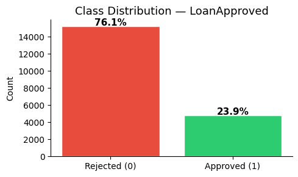

```
LoanApproved
0    15220
1     4780
Name: count, dtype: int64
```

```python
# ── 2a: Class balance ─────────────────────────────────────────────────────────
# This is the most important single fact about the dataset.
# A severe imbalance means ACCURACY IS A USELESS METRIC here: a model that
# rejects everyone would score ~76% accuracy while being entirely useless.
# We will use ROC-AUC and PR-AUC instead (explained in Section 4).

counts = df[TARGET].value_counts()
pct    = df[TARGET].value_counts(normalize=True) * 100

fig, ax = plt.subplots(figsize=(5, 3))
bars = ax.bar(["Rejected (0)", "Approved (1)"], counts.values,
              color=["#e74c3c", "#2ecc71"], edgecolor="white")
for bar, p in zip(bars, pct.values):
    ax.text(bar.get_x() + bar.get_width()/2, bar.get_height() + 100,
            f"{p:.1f}%", ha="center", fontsize=11, fontweight="bold")
ax.set_title("Class Distribution — LoanApproved", fontsize=13)
ax.set_ylabel("Count")
sns.despine()
fig.tight_layout()
fig.savefig(ARTIFACTS / "class_balance.png", dpi=150)
plt.show()
print(counts)
```

Here we plot each numeric feature twice — once for approved applicants, once for rejected — so we can visually spot which features separate the two groups most clearly. The ones with the biggest gap between the red and green distributions will likely be the most powerful predictors.

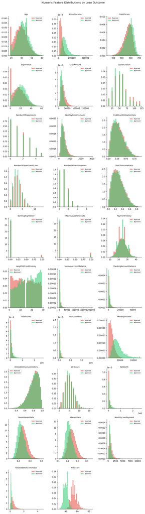

```python
# ── 2b: Numeric feature distributions split by outcome ────────────────────────
# Look at which features show the clearest separation between approved and
# rejected applicants — these will likely appear high in the SHAP plot later.

numeric_cols = df.select_dtypes(include="number").columns
numeric_cols = [c for c in numeric_cols if c not in [TARGET]]

n = len(numeric_cols)
cols = 3
rows = (n + cols - 1) // cols

fig, axes = plt.subplots(rows, cols, figsize=(10, rows * 3.5))
axes = axes.flatten()

for i, col in enumerate(numeric_cols):
    for label, colour in [(0, "#e74c3c"), (1, "#2ecc71")]:
        subset = df[df[TARGET] == label][col].dropna()
        axes[i].hist(subset, bins=30, alpha=0.55, color=colour,
                     label="Rejected" if label == 0 else "Approved",
                     density=True)
    axes[i].set_title(col, fontsize=9)
    axes[i].legend(fontsize=7)
    sns.despine(ax=axes[i])

for j in range(i + 1, len(axes)):
    axes[j].set_visible(False)

fig.suptitle("Numeric Feature Distributions by Loan Outcome", fontsize=13, y=1.01)
fig.tight_layout()
fig.savefig(ARTIFACTS / "feature_distributions.png", dpi=150, bbox_inches="tight")
plt.show()
```

This heatmap shows how strongly every pair of features moves together. We check this early because highly correlated features carry overlapping information, which matters when we interpret the model's explanations later — if two features are nearly identical, crediting one over the other is somewhat arbitrary.

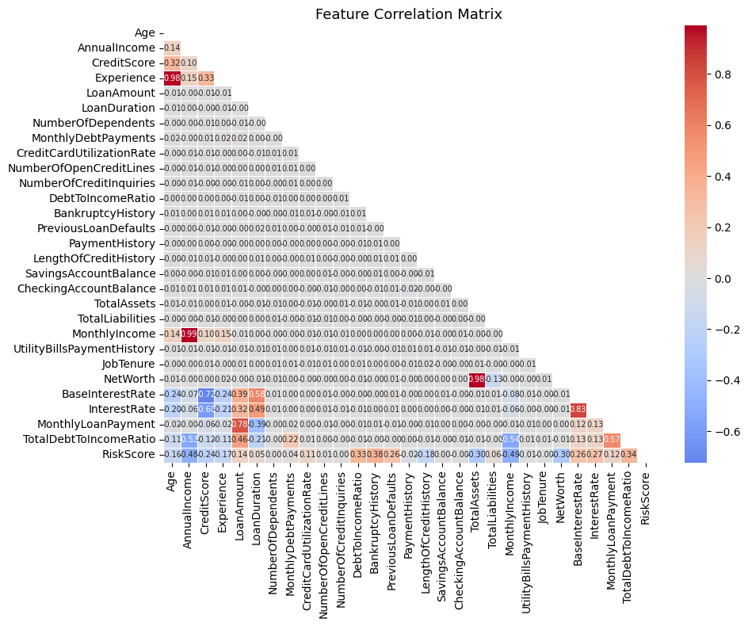

```python
# ── 2c: Correlation heatmap (numeric features only) ───────────────────────────
corr = df[numeric_cols].corr()

fig, ax = plt.subplots(figsize=(10, 8))
mask = np.triu(np.ones_like(corr, dtype=bool))  # show lower triangle only
sns.heatmap(corr, mask=mask, annot=True, fmt=".2f", cmap="coolwarm",
            center=0, linewidths=0.5, ax=ax, annot_kws={"size": 7})
ax.set_title("Feature Correlation Matrix", fontsize=13)
fig.tight_layout()
fig.savefig(ARTIFACTS / "correlation_heatmap.png", dpi=150)
plt.show()
```

## 3 · Time-Based Train / Test Split

**Why not a random split?**  
A bank trains its model on past applicants and scores future ones. A random split allows the model to implicitly learn from future data points during training, which inflates evaluation metrics and misrepresents real-world performance. Sorting by `ApplicationDate` and holding out the most recent 20% is the deployment-realistic approach.

In short: we sort the entire dataset by date, train on the older 80%, and test on the newest 20% — so the model is always evaluated on applicants it has genuinely never seen before.

```python
df_sorted = df.sort_values(DATE_COL).reset_index(drop=True)
split_idx = int(len(df_sorted) * (1 - TEST_SIZE))

train_df = df_sorted.iloc[:split_idx].copy()
test_df  = df_sorted.iloc[split_idx:].copy()

feature_cols = [c for c in df.columns if c not in DROP_COLS + [TARGET]]

X_train, y_train = train_df[feature_cols], train_df[TARGET]
X_test,  y_test  = test_df[feature_cols],  test_df[TARGET]

print(f"Training rows : {len(X_train):,}")
print(f"Test rows     : {len(X_test):,}")
print(f"Train approval rate: {y_train.mean():.3f}")
print(f"Test  approval rate: {y_test.mean():.3f}")
print("\n→ Approval rates are stable across the split — no temporal drift.")
```

```
Training rows : 16,000
Test rows     : 4,000
Train approval rate: 0.239
Test  approval rate: 0.238

→ Approval rates are stable across the split — no temporal drift.
```

## 4 · Preprocessing Pipeline

Column types are **auto-detected** so the pipeline survives minor schema changes.

- **Numeric**: median imputation (robust to income/debt skew) + standard scaling
- **Categorical**: most-frequent imputation + one-hot encoding

This pipeline does two things at once: it cleans the data and remembers exactly how it did so, which means any new applicant that comes in later gets cleaned the exact same way without any manual effort.

```python
numeric_features     = X_train.select_dtypes(include="number").columns.tolist()
categorical_features = X_train.select_dtypes(exclude="number").columns.tolist()

print(f"Numeric features ({len(numeric_features)}):    {numeric_features}")
print(f"Categorical features ({len(categorical_features)}): {categorical_features}")

numeric_transformer = Pipeline([
    ("imputer", SimpleImputer(strategy="median")),
    ("scaler",  StandardScaler()),
])

categorical_transformer = Pipeline([
    ("imputer",  SimpleImputer(strategy="most_frequent")),
    ("onehot",   OneHotEncoder(handle_unknown="ignore", sparse_output=False)),
])

preprocessor = ColumnTransformer([
    ("num", numeric_transformer,     numeric_features),
    ("cat", categorical_transformer, categorical_features),
])

print("\n✓ Preprocessor built.")
```

```
Numeric features (28):    ['Age', 'AnnualIncome', 'CreditScore', 'Experience', 'LoanAmount', 'LoanDuration', 'NumberOfDependents', 'MonthlyDebtPayments', 'CreditCardUtilizationRate', 'NumberOfOpenCreditLines', 'NumberOfCreditInquiries', 'DebtToIncomeRatio', 'BankruptcyHistory', 'PreviousLoanDefaults…
Categorical features (5): ['EmploymentStatus', 'EducationLevel', 'MaritalStatus', 'HomeOwnershipStatus', 'LoanPurpose']

✓ Preprocessor built.
```

## 5 · Model Training

### 5a · Logistic Regression — Interpretable Baseline

`class_weight='balanced'` reweights the loss so the minority (Approved) class is not drowned out. Every serious imbalanced-classification project needs a baseline.

We train this simpler model first not because it is the best, but because it gives us a transparent benchmark — if the complex model later cannot beat it meaningfully, the added complexity was not worth it.

```python
logreg_pipeline = Pipeline([
    ("prep", preprocessor),
    ("clf",  LogisticRegression(
        max_iter=1000,
        class_weight="balanced",   # handles the ~76/24 imbalance
        random_state=RANDOM_SEED,
    )),
])

logreg_pipeline.fit(X_train, y_train)
print("✓ Logistic Regression trained.")
```

```
✓ Logistic Regression trained.
```

### 5b · XGBoost — Primary Model

`scale_pos_weight` = (# rejected) / (# approved) is XGBoost's built-in imbalance correction. It tells the model to penalise missing an approval more heavily than misclassifying a rejection.

XGBoost builds its answer by training hundreds of small decision trees in sequence, where each new tree focuses specifically on the cases the previous trees got wrong — the result is a highly accurate model that still lets SHAP see inside it.

```python
neg, pos = (y_train == 0).sum(), (y_train == 1).sum()
scale_pos_weight = neg / pos
print(f"Class ratio (neg/pos): {scale_pos_weight:.2f}")

# XGBoost is scale-invariant so we skip StandardScaler in the preprocessor.
# We rebuild a simpler preprocessor without scaling for this model.
preprocessor_noscale = ColumnTransformer([
    ("num", SimpleImputer(strategy="median"),  numeric_features),
    ("cat", Pipeline([
        ("imp", SimpleImputer(strategy="most_frequent")),
        ("ohe", OneHotEncoder(handle_unknown="ignore", sparse_output=False)),
    ]), categorical_features),
])

xgb_pipeline = Pipeline([
    ("prep", preprocessor_noscale),
    ("clf",  XGBClassifier(
        n_estimators=400,
        max_depth=5,
        learning_rate=0.05,
        subsample=0.8,
        colsample_bytree=0.8,
        scale_pos_weight=scale_pos_weight,
        eval_metric="logloss",
        random_state=RANDOM_SEED,
        n_jobs=-1,
    )),
])

xgb_pipeline.fit(X_train, y_train)
print("✓ XGBoost trained.")
```

```
Class ratio (neg/pos): 3.18
```

```
✓ XGBoost trained.
```

## 6 · Evaluation

**Why not accuracy?**  
With 76% rejected applications, a trivial model that always says 'Reject' achieves ~76% accuracy — making accuracy meaningless. We evaluate on:

- **ROC-AUC**: model's ability to rank applicants by approval probability
- **PR-AUC**: precision-recall tradeoff on the minority (Approved) class — more informative under imbalance
- **Per-class Recall**: ensures the model is not simply ignoring approvals

Because accuracy is misleading when most cases are rejections, we measure the model on two fairer scales: how well it ranks applicants (ROC-AUC) and how precisely it identifies the rare approvals without flooding the output with false positives (PR-AUC).

```
==================================================
  Logistic Regression
==================================================
  ROC-AUC : 0.9944
  PR-AUC  : 0.9833

              precision    recall  f1-score   support

    Rejected       0.99      0.95      0.97      3048
    Approved       0.86      0.97      0.91       952

    accuracy                           0.96      4000
   macro avg       0.93      0.96      0.94      4000
weighted avg       0.96      0.96      0.96      4000
```

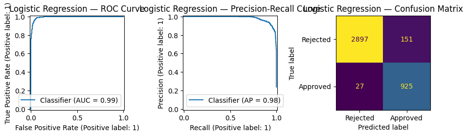

```
==================================================
  XGBoost
==================================================
  ROC-AUC : 0.9931
  PR-AUC  : 0.9793

              precision    recall  f1-score   support

    Rejected       0.99      0.96      0.97      3048
    Approved       0.87      0.96      0.91       952

    accuracy                           0.96      4000
   macro avg       0.93      0.96      0.94      4000
weighted avg       0.96      0.96      0.96      4000
```

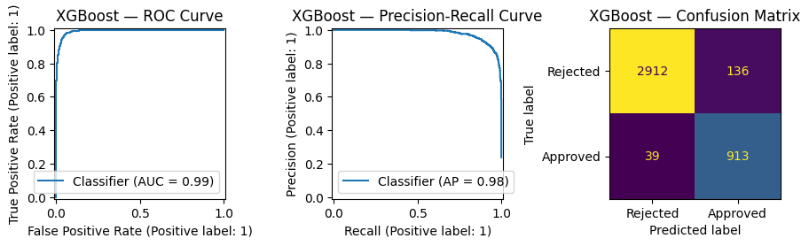

```python
def evaluate_model(name, pipeline, X_test, y_test, save=True):
    proba = pipeline.predict_proba(X_test)[:, 1]
    preds = pipeline.predict(X_test)

    roc = roc_auc_score(y_test, proba)
    pra = average_precision_score(y_test, proba)

    print(f"\n{'='*50}")
    print(f"  {name}")
    print(f"{'='*50}")
    print(f"  ROC-AUC : {roc:.4f}")
    print(f"  PR-AUC  : {pra:.4f}")
    print(f"\n{classification_report(y_test, preds, target_names=['Rejected','Approved'])}")

    if save:
        fig, axes = plt.subplots(1, 3, figsize=(9, 4))

        RocCurveDisplay.from_predictions(y_test, proba, ax=axes[0])
        axes[0].set_title(f"{name} — ROC Curve")

        PrecisionRecallDisplay.from_predictions(y_test, proba, ax=axes[1])
        axes[1].set_title(f"{name} — Precision-Recall Curve")

        ConfusionMatrixDisplay.from_predictions(
            y_test, preds,
            display_labels=["Rejected", "Approved"],
            ax=axes[2], colorbar=False
        )
        axes[2].set_title(f"{name} — Confusion Matrix")

        fig.tight_layout()
        fname = name.lower().replace(" ", "_")
        fig.savefig(ARTIFACTS / f"{fname}_evaluation.png", dpi=150)
        plt.show()

    return {"roc_auc": roc, "pr_auc": pra}


lr_scores  = evaluate_model("Logistic Regression", logreg_pipeline, X_test, y_test)
xgb_scores = evaluate_model("XGBoost",             xgb_pipeline,    X_test, y_test)
```

This table puts both models side by side so we can see at a glance whether XGBoost's extra complexity actually earned its keep. A large gap means the sophisticated model is genuinely worth using; a small gap might mean the simpler one is good enough.

```python
# ── Model comparison table ────────────────────────────────────────────────────
comparison = pd.DataFrame({
    "Model":   ["Logistic Regression (baseline)", "XGBoost (primary)"],
    "ROC-AUC": [lr_scores["roc_auc"],  xgb_scores["roc_auc"]],
    "PR-AUC":  [lr_scores["pr_auc"],   xgb_scores["pr_auc"]],
}).set_index("Model").round(4)

print(comparison.to_string())

# Save for the report
with open(ARTIFACTS / "metrics_summary.json", "w") as f:
    json.dump({"LogReg": lr_scores, "XGBoost": xgb_scores}, f, indent=2)
```

```
                                ROC-AUC  PR-AUC
Model
Logistic Regression (baseline)   0.9944  0.9833
XGBoost (primary)                0.9931  0.9793
```

## 7 · Explainability with SHAP

SHAP (SHapley Additive exPlanations) assigns each feature a contribution score for a given prediction. Unlike feature importance from a model's internal weights, SHAP values are **consistent** and **locally accurate** — they sum to the model's actual output.

We produce two plot types:

- **Global (Summary Plot)**: Which features matter most across all applicants?
- **Local (Waterfall Plot)**: Why was *this specific applicant* approved or rejected?

SHAP works by asking, for each feature, how much the prediction changes when that feature is included versus left out — averaged fairly across every possible combination. The result is a precise, honest measure of each feature's contribution to each individual decision.

```python
# Transform the test set through the preprocessing step so we feed the
# XGBoost model the same numeric array it was trained on.
prep_step  = xgb_pipeline.named_steps["prep"]
model_step = xgb_pipeline.named_steps["clf"]

X_test_transformed = prep_step.transform(X_test)

# Recover human-readable feature names after one-hot encoding.
try:
    feature_names = prep_step.get_feature_names_out()
    feature_names = [n.replace("num__", "").replace("cat__", "") for n in feature_names]
except Exception:
    feature_names = [f"feature_{i}" for i in range(X_test_transformed.shape[1])]

explainer   = shap.TreeExplainer(model_step)
shap_values = explainer.shap_values(X_test_transformed)

print(f"✓ SHAP values computed for {len(shap_values)} test samples.")
print(f"   Features in SHAP output: {len(feature_names)}")
```

```
✓ SHAP values computed for 4000 test samples.
   Features in SHAP output: 49
```

This is the global view — one dot per applicant, showing how each feature pushed each person's prediction toward approval or rejection. Reading the plot top to bottom gives you the rank order of what matters most across the entire dataset.

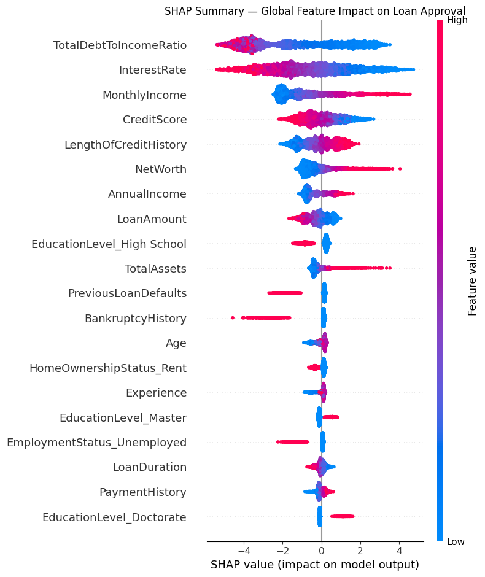

```python
# ── 7a: Global Summary Plot ───────────────────────────────────────────────────
# Each dot is one applicant. Colour = feature value (red=high, blue=low).
# Position on X = SHAP value = impact on the prediction.
# Features are ranked by mean absolute SHAP value (overall importance).
#
# WHAT TO WRITE IN YOUR REPORT: Name the top 3-4 features and describe
# the direction of their effect. E.g. 'High TotalDebtToIncomeRatio
# (red dots) pushes predictions toward Rejection (negative SHAP values).'

plt.figure(figsize=(4, 2))
shap.summary_plot(shap_values, X_test_transformed,
                  feature_names=feature_names, show=False)
plt.title("SHAP Summary — Global Feature Impact on Loan Approval", fontsize=12)
plt.tight_layout()
plt.savefig(ARTIFACTS / "shap_global_summary.png", dpi=150, bbox_inches="tight")
plt.show()
```

We now zoom into one individual — the applicant the model was most confident approving — and trace exactly which features drove that decision and by how much. This is the kind of explanation a loan officer could read directly to a customer.

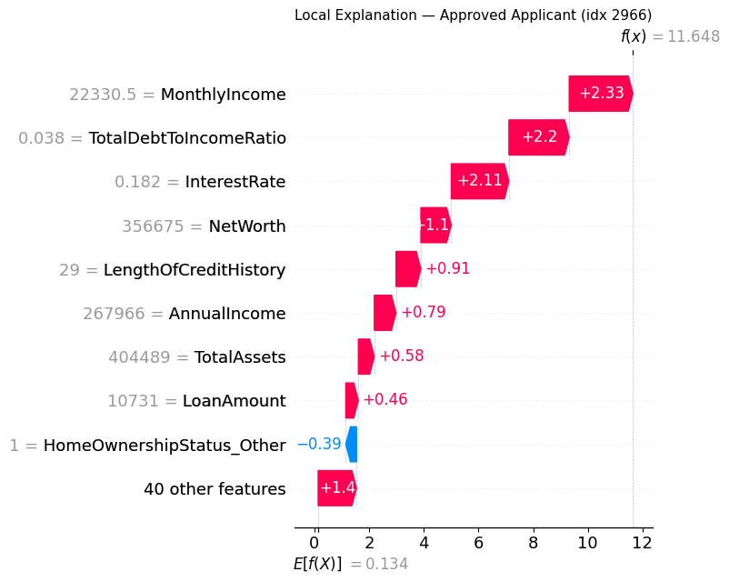

```
Model approval probability for this applicant: 1.000
```

```python
# ── 7b: Local Waterfall Plot — Approved Applicant ────────────────────────────
# Pick the test applicant the model is MOST confident is approved.
# The waterfall shows exactly which features pushed the model toward Approve.
#
# WHAT TO WRITE: 'For Applicant #N, the model approved the loan with
# probability X. The largest positive contributor was [feature], which
# added [SHAP] to the log-odds score. This constitutes an explanation
# a loan officer can present to the applicant under GDPR Article 22.'

probas = xgb_pipeline.predict_proba(X_test)[:, 1]
most_approved_idx = int(np.argmax(probas))

explanation = shap.Explanation(
    values        = shap_values[most_approved_idx],
    base_values   = explainer.expected_value,
    data          = X_test_transformed[most_approved_idx],
    feature_names = feature_names,
)

plt.figure(figsize=(4, 2))
shap.plots.waterfall(explanation, show=False)
plt.title(f"Local Explanation — Approved Applicant (idx {most_approved_idx})",
          fontsize=11)
plt.tight_layout()
plt.savefig(ARTIFACTS / "shap_local_approved.png", dpi=150, bbox_inches="tight")
plt.show()
print(f"Model approval probability for this applicant: {probas[most_approved_idx]:.3f}")
```

Same breakdown, but for the applicant the model was most confident rejecting. Comparing this plot with the approved one above makes it immediately visible what separates a strong application from a weak one in the model's eyes.

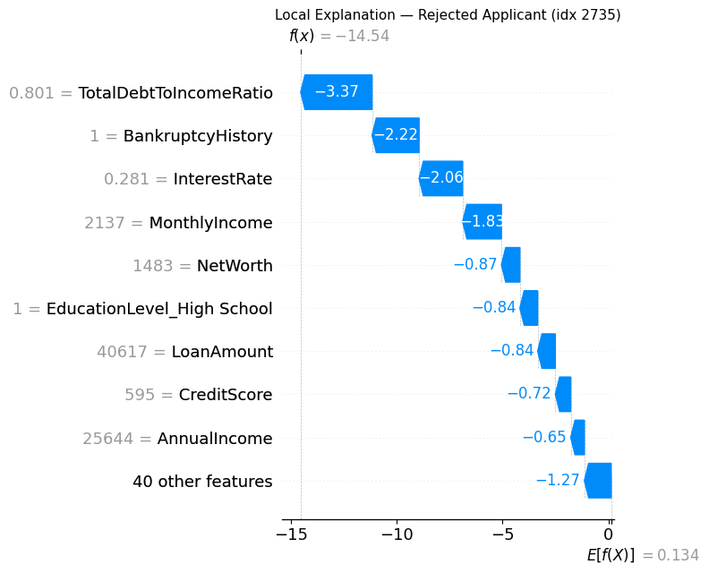

```
Model approval probability for this applicant: 0.000
```

```python
# ── 7c: Local Waterfall Plot — Rejected Applicant ────────────────────────────
# Same idea for the most confidently rejected applicant.
# Having both approved and rejected explanations makes the business demo
# concrete: a loan officer can look at either outcome and understand it.

most_rejected_idx = int(np.argmin(probas))

explanation_rej = shap.Explanation(
    values        = shap_values[most_rejected_idx],
    base_values   = explainer.expected_value,
    data          = X_test_transformed[most_rejected_idx],
    feature_names = feature_names,
)

plt.figure(figsize=(4, 2))
shap.plots.waterfall(explanation_rej, show=False)
plt.title(f"Local Explanation — Rejected Applicant (idx {most_rejected_idx})",
          fontsize=11)
plt.tight_layout()
plt.savefig(ARTIFACTS / "shap_local_rejected.png", dpi=150, bbox_inches="tight")
plt.show()
print(f"Model approval probability for this applicant: {probas[most_rejected_idx]:.3f}")
```

We install DiCE, the library that generates counterfactual explanations — the tool that will tell a rejected applicant not just why they were turned down, but what specific changes would flip the decision to an approval.

```python
!pip install dice-ml
```

```
Downloading dice_ml-0.12-py3-none-any.whl (2.5 MB)
   ━━━━━━╸━━━━━━━━━━━━━━━━━━━━━━━━━━━━━━━━━ 0.4/2.5 MB 13.7 MB/s eta 0:00:01
```

```
   ━━━━━━━━━━━━━━━━━━━━━━━━━━━━━━━━━━━━━━━━ 2.5/2.5 MB 31.9 MB/s eta 0:00:00
Downloading raiutils-0.4.2-py3-none-any.whl (17 kB)
```

### 7d · Counterfactual Explanations (DiCE)

SHAP tells the applicant **why** they were rejected.  
Counterfactuals tell them **what to change** to get approved.

*"If your debt-to-income ratio were 0.45 instead of 0.72, your loan would be approved."*

**Install once:** `pip install dice-ml`

```python
import dice_ml
from dice_ml import Dice

# DiCE needs the raw (un-preprocessed) data and the full sklearn Pipeline.
# It will probe the model with small perturbations to find the minimum
# change required to flip the prediction.

train_for_dice = X_train.copy()
train_for_dice[TARGET] = y_train.values

d = dice_ml.Data(
    dataframe         = train_for_dice,
    continuous_features = numeric_features,
    outcome_name      = TARGET,
)
m = dice_ml.Model(model=xgb_pipeline, backend="sklearn")
exp = Dice(d, m, method="random")

# Pick a rejected applicant to generate a counterfactual for.
# We use the SAME one we explained with SHAP in 7c, so the report
# tells one continuous story about the same person.
query = X_test.iloc[[most_rejected_idx]]

cf = exp.generate_counterfactuals(
    query,
    total_CFs    = 3,        # show 3 different ways to flip the decision
    desired_class = 1,       # we want Approved (1)
)

print("=" * 60)
print("  ORIGINAL APPLICANT (predicted: Rejected)")
print("=" * 60)
print(query.T.to_string())

print("\n" + "=" * 60)
print("  COUNTERFACTUALS (what to change for Approval)")
print("=" * 60)
cf.visualize_as_dataframe(show_only_changes=True)
```

```
============================================================
  ORIGINAL APPLICANT (predicted: Rejected)
============================================================
                                  18735
Age                                  31
AnnualIncome                      25644
CreditScore                         595
EmploymentStatus               Employed
EducationLevel              High School
Experience                            8
LoanAmount                        40617
LoanDuration                         60
MaritalStatus                   Married
NumberOfDependents                    1
HomeOwnershipStatus            Mortgage
MonthlyDebtPayments                 446
CreditCardUtilizationRate       0.69356
NumberOfOpenCreditLines               2
NumberOfCreditInquiries               0
DebtToIncomeRatio              0.113736
BankruptcyHistory                     1
LoanPurpose                        Home
PreviousLoanDefaults                  0
PaymentHistory                       19
LengthOfCreditHistory                12
SavingsAccountBalance             15162
CheckingAccountBalance             1261
TotalAssets                       63232
TotalLiabilities                  61749
MonthlyIncome                    2137.0
UtilityBillsPaymentHistory     0.638749
JobTenure                             9
NetWorth                           1483
BaseInterestRate               0.248117
InterestRate                   0.280543
MonthlyLoanPayment          1265.974546
TotalDebtToIncomeRatio         0.801111

============================================================
  COUNTERFACTUALS (what to change for Approval)
============================================================
Query instance (original outcome : 0)
```

|  | Age | AnnualIncome | CreditScore | EmploymentStatus | EducationLevel | Experience | LoanAmount | LoanDuration | MaritalStatus | NumberOfDependents | ... | TotalLiabilities | MonthlyIncome | UtilityBillsPaymentHistory | JobTenure | NetWorth | BaseInterestRate | InterestRate | MonthlyLoanPayment | TotalDebtToIncomeRatio | LoanApproved |
| --- | --- | --- | --- | --- | --- | --- | --- | --- | --- | --- | --- | --- | --- | --- | --- | --- | --- | --- | --- | --- | --- |
| 0 | 31 | 25644 | 595 | Employed | High School | 8 | 40617 | 60 | Married | 1 | ... | 61749 | 2137.0 | 0.638749 | 9 | 1483 | 0.248117 | 0.280543 | 1265.974487 | 0.801111 | 0 |

1 rows × 34 columns

```
Diverse Counterfactual set (new outcome: 1)
```

|  | Age | AnnualIncome | CreditScore | EmploymentStatus | EducationLevel | Experience | LoanAmount | LoanDuration | MaritalStatus | NumberOfDependents | ... | TotalLiabilities | MonthlyIncome | UtilityBillsPaymentHistory | JobTenure | NetWorth | BaseInterestRate | InterestRate | MonthlyLoanPayment | TotalDebtToIncomeRatio | LoanApproved |
| --- | --- | --- | --- | --- | --- | --- | --- | --- | --- | --- | --- | --- | --- | --- | --- | --- | --- | --- | --- | --- | --- |
| 0 | - | - | 358 | Self-Employed | - | - | - | - | - | - | ... | - | 17540.6 | - | - | 1654778 | 0.377718 | 0.21487182 | - | 4.30428023 | 1 |
| 1 | - | - | 442 | - | - | - | - | - | - | - | ... | - | 22212.9 | - | 3 | 947720 | - | - | 3361.35424 | 3.70843578 | 1 |
| 2 | - | - | - | - | - | - | - | - | - | - | ... | - | - | - | - | 2379566 | 0.23866 | - | 705.57368 | 0.06367173 | 1 |

3 rows × 34 columns

## 8 · Summary of Findings

This final cell prints a clean summary of the whole project in one block — useful as a screenshot for your report's Results section and as a quick sanity check that everything ran as expected.

```python
print("=" * 55)
print("  PROJECT RESULTS SUMMARY")
print("=" * 55)
print(f"  Dataset rows  : {len(df):,}")
print(f"  Features used : {len(feature_cols)}")
print(f"  Train / Test  : {len(X_train):,} / {len(X_test):,} (time-based)")
print(f"  Class balance : {(y_train==1).mean()*100:.1f}% approved (train)")
print()
print(f"  Logistic Regression  →  ROC-AUC: {lr_scores['roc_auc']:.4f}  "
      f"| PR-AUC: {lr_scores['pr_auc']:.4f}")
print(f"  XGBoost (primary)    →  ROC-AUC: {xgb_scores['roc_auc']:.4f}  "
      f"| PR-AUC: {xgb_scores['pr_auc']:.4f}")
print()
print("  Artifacts saved to ../artifacts/:")
for f in sorted(ARTIFACTS.iterdir()):
    print(f"    {f.name}")
print("=" * 55)
```

```
=======================================================
  PROJECT RESULTS SUMMARY
=======================================================
  Dataset rows  : 20,000
  Features used : 33
  Train / Test  : 16,000 / 4,000 (time-based)
  Class balance : 23.9% approved (train)

  Logistic Regression  →  ROC-AUC: 0.9944  | PR-AUC: 0.9833
  XGBoost (primary)    →  ROC-AUC: 0.9931  | PR-AUC: 0.9793

  Artifacts saved to ../artifacts/:
    class_balance.png
    correlation_heatmap.png
    feature_distributions.png
    logistic_regression_evaluation.png
    metrics_summary.json
    shap_global_summary.png
    shap_local_approved.png
    shap_local_rejected.png
    xgboost_evaluation.png
=======================================================
```